# Лабораторная работа №2

## Аналоговые фильтры. Вариант 6

**Студент:** Ким Игорь Геннадьевич  
**Курс:** НИС КНТ, 3 курс  
**Тема:** сигналы и фильтры

### Что требуется сделать

В этой работе используется сигнал из ДЗ-1 и выполняется его фильтрация двумя способами:

1. через идеальный фильтр с полосой пропускания $$[-\lambda_F,\lambda_F]$$;
2. через RC-цепочку, которая рассматривается как аппроксимация идеального фильтра.

По условию нужно:

- выделить частоты ярко выраженных колебаний;
- подобрать полосу $$[-\lambda_F,\lambda_F]$$;
- пропустить сигнал через идеальный фильтр:
  - через прямое и обратное преобразования Фурье;
  - через свёртку с функцией отклика;
- сравнить результаты;
- подобрать параметры RC-цепочки;
- пропустить сигнал через RC-цепочку:
  - через передаточную функцию и ОПФ;
  - через свёртку с функцией отклика;
- сравнить результаты между собой и с идеальным фильтром.

Во всех вычислениях ниже **не используется БПФ**. Прямое и обратное преобразования Фурье считаются **явно по матричным формулам**, как и требуется в методичке.

## 1. Исходный сигнал из ДЗ-1

Для варианта 6 из предыдущей работы использовался сигнал

$$ x(t)=2\,\mathrm{sinc}(4t)+e^{-0.3t^2}\cos(8\pi t). $$

Здесь:

- первое слагаемое $$2\,\mathrm{sinc}(4t)$$ создаёт **низкочастотную** составляющую;
- второе слагаемое $$e^{-0.3t^2}\cos(8\pi t)$$ - это гармоническое колебание с частотой около $$\lambda=\pm 4$$, умноженное на гауссово окно.

Из ДЗ-1 уже известно:

- у $$\mathrm{sinc}$$-части спектр сосредоточен в полосе около нуля;
- у гауссово-модулированной косинусоиды возникают два ярких спектральных пика около $$\lambda=\pm 4$$.

Значит, если цель фильтрации - убрать именно заметные колебания, то нужно сохранить окрестность нуля и отрезать область около $$\pm 4$$.

```python
import numpy as np
import matplotlib.pyplot as plt
import pandas as pd

plt.style.use("seaborn-v0_8-whitegrid")
plt.rcParams.update({
  "figure.figsize": (12, 4.8),
  "figure.dpi": 130,
  "axes.grid": True,
  "axes.axisbelow": True,
  "axes.spines.top": False,
  "axes.spines.right": False,
  "axes.titlesize": 13,
  "axes.labelsize": 11,
  "font.size": 11,
  "lines.linewidth": 2,
})

A3 = 2.0
B3 = 4.0
D3 = 0.3
W3 = 4.0

def signal(t: np.ndarray) -> np.ndarray:
  return A3 * np.sinc(B3 * t) + np.exp(-D3 * t**2) * np.cos(2 * np.pi * W3 * t)

def analytic_spectrum(lam: np.ndarray) -> np.ndarray:
  rect = np.where(np.abs(lam) <= 2.0, 1.0, 0.0)
  sinc_part = 0.5 * rect
  gauss_part = 0.5 * np.sqrt(np.pi / D3) * (
    np.exp(-(np.pi**2) * (lam - W3) ** 2 / D3)
    + np.exp(-(np.pi**2) * (lam + W3) ** 2 / D3)
  )
  return sinc_part + gauss_part

def forward_fourier_chunked(t: np.ndarray, x: np.ndarray, lam: np.ndarray, chunk: int = 256) -> np.ndarray:
  a = t[1] - t[0]
  X = np.zeros_like(lam, dtype=np.complex128)
  for start in range(0, len(lam), chunk):
    stop = min(start + chunk, len(lam))
    lam_chunk = lam[start:stop]
    kernel = np.exp(-2j * np.pi * np.outer(t, lam_chunk))
    X[start:stop] = a * (x[:, None] * kernel).sum(axis=0)
  return X

def inverse_fourier_chunked(lam: np.ndarray, G: np.ndarray, t: np.ndarray, chunk: int = 256) -> np.ndarray:
  s = lam[1] - lam[0]
  x = np.zeros_like(t, dtype=np.complex128)
  for start in range(0, len(lam), chunk):
    stop = min(start + chunk, len(lam))
    lam_chunk = lam[start:stop]
    G_chunk = G[start:stop]
    kernel = np.exp(2j * np.pi * np.outer(lam_chunk, t))
    x += s * (G_chunk[:, None] * kernel).sum(axis=0)
  return x

def conv_on_same_grid(t: np.ndarray, x: np.ndarray, th: np.ndarray, h: np.ndarray):
  a = t[1] - t[0]
  y_full = a * np.convolve(x, h, mode="full")
  y_tmin = t[0] + th[0]
  t_full = y_tmin + a * np.arange(len(y_full))
  idx = np.round((t - y_tmin) / a).astype(int)
  y = y_full[idx]
  return y, t_full, y_full

def rel_error(u: np.ndarray, v: np.ndarray) -> float:
  return float(np.linalg.norm(u - v) / np.linalg.norm(v))

def masked_phase(z: np.ndarray, threshold: float = 1e-4) -> np.ndarray:
  out = np.angle(z).copy()
  out[np.abs(z) < threshold] = np.nan
  return out
```

## 2. Выбор интервалов и шагов дискретизации

Возьмём:

- временной интервал $$ [t_{\min}, t_{\max}] = [-12.8,\,12.8]; $$
- частотный интервал $$ [\lambda_{\min}, \lambda_{\max}] = [-40,\,40]; $$
- число точек по времени $$ N = 2048; $$
- число точек по частоте $$ M = 4096. $$

Тогда шаги равны

$$ a=\frac{t_{\max}-t_{\min}}{N}, \qquad s=\frac{\lambda_{\max}-\lambda_{\min}}{M}. $$

Почему такой выбор разумен:

1. интервал по времени достаточно широкий, чтобы увидеть хвосты $$\mathrm{sinc}$$-слагаемого и ослабить краевые эффекты;
2. интервал по частоте сильно шире области полезного спектра, поэтому ОПФ для RC-фильтра восстанавливается устойчивее;
3. шаг по времени получается достаточно малым для RC-цепочки, у которой функция отклика быстро меняется около $$t=0$$.

Именно на этой сетке ниже выполняются все сравнения.

```python
tmin, tmax, N = -12.8, 12.8, 2048
lmin, lmax, M = -40.0, 40.0, 4096

a = (tmax - tmin) / N
s = (lmax - lmin) / M

t = tmin + a * np.arange(N)
lam = lmin + s * np.arange(M)

x = signal(t)
X = forward_fourier_chunked(t, x, lam, chunk=256)

print(f"tmin = {tmin}")
print(f"tmax = {tmax}")
print(f"N = {N}")
print(f"a = {a:.6f}")
print()
print(f"lambda_min = {lmin}")
print(f"lambda_max = {lmax}")
print(f"M = {M}")
print(f"s = {s:.6f}")
print()
print(f"max |Im x(t)| = {np.max(np.abs(np.imag(x))):.3e}")
```

```
tmin = -12.8
tmax = 12.8
N = 2048
a = 0.012500

lambda_min = -40.0
lambda_max = 40.0
M = 4096
s = 0.019531

max |Im x(t)| = 0.000e+00
```

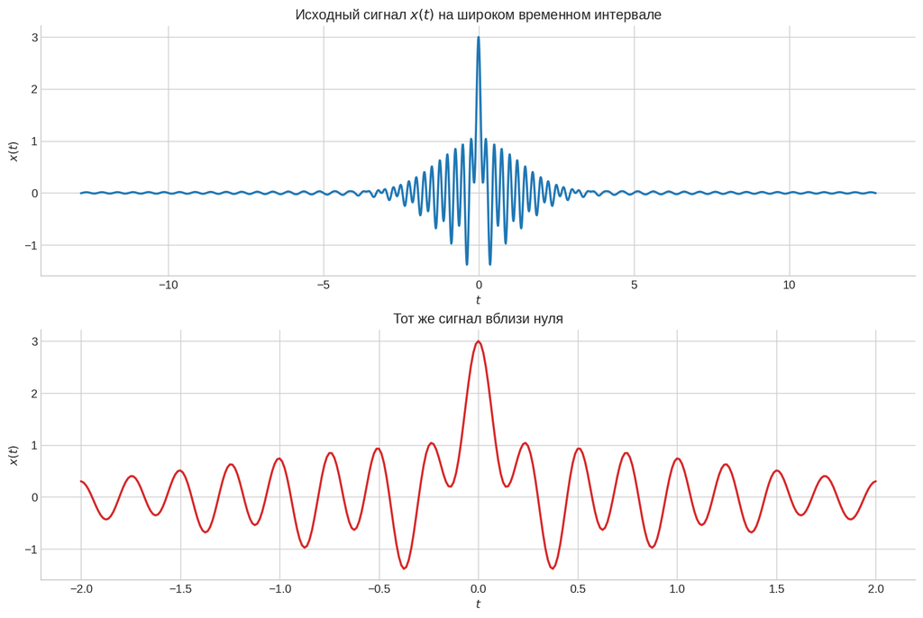

```python
fig, axes = plt.subplots(2, 1, figsize=(12, 8), constrained_layout=True)

axes[0].plot(t, x, color="#1f77b4")
axes[0].set_title("Исходный сигнал $x(t)$ на широком временном интервале")
axes[0].set_xlabel("$t$")
axes[0].set_ylabel("$x(t)$")

mask_zoom = (t >= -2.0) & (t <= 2.0)
axes[1].plot(t[mask_zoom], x[mask_zoom], color="#d62728")
axes[1].set_title("Тот же сигнал вблизи нуля")
axes[1].set_xlabel("$t$")
axes[1].set_ylabel("$x(t)$")

plt.show()
```

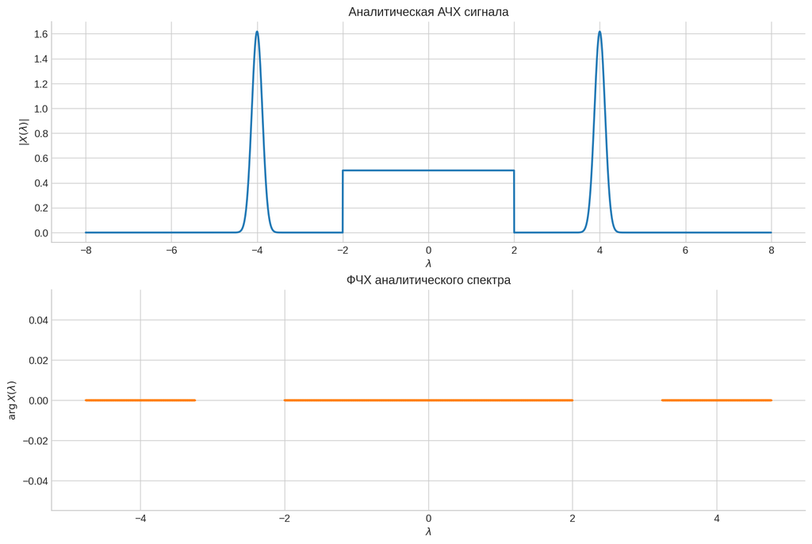

```python
lam_view = np.linspace(-8, 8, 5000)
X_true_view = analytic_spectrum(lam_view)

fig, axes = plt.subplots(2, 1, figsize=(12, 8), constrained_layout=True)

axes[0].plot(lam_view, np.abs(X_true_view), color="#1f77b4")
axes[0].set_title("Аналитическая АЧХ сигнала")
axes[0].set_xlabel("$\\lambda$")
axes[0].set_ylabel("$|X(\\lambda)|$")

axes[1].plot(lam_view, masked_phase(X_true_view, 1e-8), ".-", markersize=2, color="#ff7f0e")
axes[1].set_title("ФЧХ аналитического спектра")
axes[1].set_xlabel("$\\lambda$")
axes[1].set_ylabel("$\\arg X(\\lambda)$")

plt.show()
```

### Комментарий к спектру

По графику АЧХ видно две разные зоны:

1. **область около нуля** - это вклад от $$2\,\mathrm{sinc}(4t)$$;
2. **два выраженных пика около $$\lambda=\pm 4$$** - это вклад от $$e^{-0.3t^2}\cos(8\pi t)$$.

Поэтому разумно выбрать полосу пропускания так, чтобы:

- весь низкочастотный вклад остался внутри полосы;
- пики около $$\pm 4$$ оказались вне полосы.

Выбираем

$$ \lambda_F = 3. $$

Тогда полоса пропускания идеального фильтра равна

$$ [-3,\,3]. $$

При таком выборе:

- поддержка $$\mathrm{sinc}$$-части, фактически лежащая внутри $$[-2,2]$$, проходит;
- ярко выраженные колебательные пики около $$\pm 4$$ отсекаются.

## 3. Идеальный фильтр с полосой пропускания $$[-\lambda_F,\lambda_F]$$

Передаточная функция идеального фильтра:

$$ H_{\mathrm{id}}(\lambda)= \begin{cases} 1, & |\lambda|\le \lambda_F, \\ 0, & |\lambda|>\lambda_F. \end{cases} $$

Для выбранного $$\lambda_F=3$$ это просто прямоугольное окно по частоте.

Функция отклика получается из ОПФ:

$$ h_{\mathrm{id}}(t)=\int_{-\lambda_F}^{\lambda_F} e^{2\pi i \lambda t}\,d\lambda. $$

После вычисления интеграла:

$$ h_{\mathrm{id}}(t)=\frac{\sin(2\pi \lambda_F t)}{\pi t}. $$

В нормировке функции $$\mathrm{sinc}(x)=\dfrac{\sin(\pi x)}{\pi x}$$ это удобно писать так:

$$ h_{\mathrm{id}}(t)=2\lambda_F\,\mathrm{sinc}(2\lambda_F t). $$

```python
lambda_F = 3.0

def ideal_transfer(lam: np.ndarray, lambda_F: float) -> np.ndarray:
  return (np.abs(lam) <= lambda_F).astype(float)

def ideal_impulse(th: np.ndarray, lambda_F: float) -> np.ndarray:
  return 2 * lambda_F * np.sinc(2 * lambda_F * th)

H_ideal = ideal_transfer(lam, lambda_F)
y_ideal_ft = inverse_fourier_chunked(lam, X * H_ideal, t, chunk=256)

th_id = np.arange(-40.0, 40.0 + a / 2, a)
h_id = ideal_impulse(th_id, lambda_F)
y_ideal_conv, t_full_id, y_full_id = conv_on_same_grid(t, x, th_id, h_id)

x_low_expected = A3 * np.sinc(B3 * t)

ideal_metrics = {
  "relative_error_methods": rel_error(y_ideal_conv.real, y_ideal_ft.real),
  "relative_error_vs_expected_lowfreq": rel_error(y_ideal_ft.real, x_low_expected),
  "max_imag_after_ft_method": float(np.max(np.abs(y_ideal_ft.imag))),
  "max_imag_after_conv_method": float(np.max(np.abs(np.imag(y_ideal_conv)))),
}
ideal_metrics
```

```
{'relative_error_methods': 2.1109394037020427e-05,
 'relative_error_vs_expected_lowfreq': 0.0016373359671352347,
 'max_imag_after_ft_method': 7.771561172376096e-16,
 'max_imag_after_conv_method': 0.0}
```

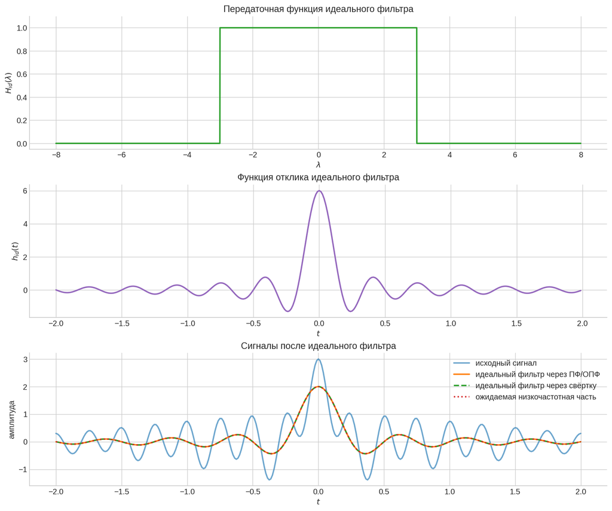

```python
fig, axes = plt.subplots(3, 1, figsize=(12, 10), constrained_layout=True)

lam_show = np.linspace(-8, 8, 4000)
axes[0].plot(lam_show, ideal_transfer(lam_show, lambda_F), color="#2ca02c")
axes[0].set_title("Передаточная функция идеального фильтра")
axes[0].set_xlabel("$\\lambda$")
axes[0].set_ylabel("$H_{id}(\\lambda)$")
axes[0].set_ylim(-0.05, 1.1)

mask_h = (th_id >= -2.0) & (th_id <= 2.0)
axes[1].plot(th_id[mask_h], h_id[mask_h], color="#9467bd")
axes[1].set_title("Функция отклика идеального фильтра")
axes[1].set_xlabel("$t$")
axes[1].set_ylabel("$h_{id}(t)$")

mask_zoom = (t >= -2.0) & (t <= 2.0)
axes[2].plot(t[mask_zoom], x[mask_zoom], label="исходный сигнал", alpha=0.65)
axes[2].plot(t[mask_zoom], y_ideal_ft.real[mask_zoom], label="идеальный фильтр через ПФ/ОПФ")
axes[2].plot(t[mask_zoom], y_ideal_conv.real[mask_zoom], "--", label="идеальный фильтр через свёртку")
axes[2].plot(t[mask_zoom], x_low_expected[mask_zoom], ":", label="ожидаемая низкочастотная часть")
axes[2].set_title("Сигналы после идеального фильтра")
axes[2].set_xlabel("$t$")
axes[2].set_ylabel("амплитуда")
axes[2].legend()

plt.show()
```

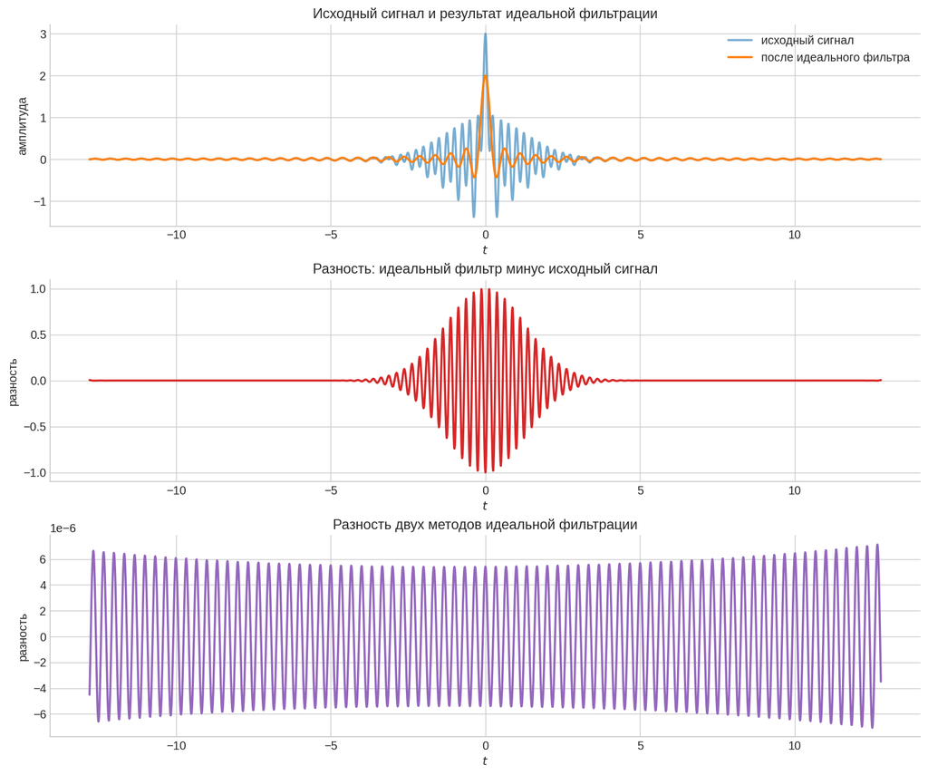

```python
fig, axes = plt.subplots(3, 1, figsize=(12, 10), constrained_layout=True)

axes[0].plot(t, x, label="исходный сигнал", alpha=0.6)
axes[0].plot(t, y_ideal_ft.real, label="после идеального фильтра")
axes[0].set_title("Исходный сигнал и результат идеальной фильтрации")
axes[0].set_xlabel("$t$")
axes[0].set_ylabel("амплитуда")
axes[0].legend()

axes[1].plot(t, y_ideal_ft.real - x, color="#d62728")
axes[1].set_title("Разность: идеальный фильтр минус исходный сигнал")
axes[1].set_xlabel("$t$")
axes[1].set_ylabel("разность")

axes[2].plot(t, y_ideal_conv.real - y_ideal_ft.real, color="#9467bd")
axes[2].set_title("Разность двух методов идеальной фильтрации")
axes[2].set_xlabel("$t$")
axes[2].set_ylabel("разность")

plt.show()
```

### Вывод по идеальному фильтру

Полученный результат хорошо согласуется с ожидаемой физикой задачи:

1. после фильтрации практически исчезают колебания, связанные с частотами около $$\pm 4$$;
2. остаётся гладкая низкочастотная часть, очень близкая к $$2\,\mathrm{sinc}(4t)$$;
3. метод через передаточную функцию и метод через свёртку дают почти один и тот же результат.

Это особенно важно для защиты: здесь видно, что выбранная полоса $$[-3,3]$$ действительно выполняет поставленную цель - удаляет именно ярко выраженную колебательную компоненту, а не искажает весь сигнал целиком.

## 4. RC-цепочка как аппроксимация идеального фильтра

Один RC-фильтр первого порядка слишком плавный: он заметно пропускает частоты около $$\lambda=\pm 4$$.
Чтобы аппроксимация была ближе к идеальному фильтру, возьмём **цепочку из двух одинаковых RC-звеньев низких частот**, соединённых последовательно.

Для одного звена:

$$ H_1(\lambda)=\frac{1}{1+i\lambda/\lambda_0}, $$

где параметр $$\lambda_0$$ связан с постоянной времени $$\tau=RC$$ формулой

$$ \lambda_0 = \frac{1}{2\pi \tau}, \qquad \tau = \frac{1}{2\pi \lambda_0}. $$

Для двух одинаковых звеньев:

$$ H_{RC}(\lambda)=\left(\frac{1}{1+i\lambda/\lambda_0}\right)^2. $$

Его функция отклика получается свёрткой двух одинаковых экспоненциальных откликов и имеет вид

$$ h_{RC}(t)=\frac{t}{\tau^2}e^{-t/\tau}\,\mathbf{1}_{\{t\ge 0\}}. $$

Дальше параметр $$\lambda_0$$ подберём численно так, чтобы модуль $$|H_{RC}(\lambda)|$$ как можно лучше приближал идеальную ступенчатую характеристику в среднем квадратичном смысле.

```python
def rc_transfer_two_stage(lam: np.ndarray, lambda0: float) -> np.ndarray:
  return 1 / (1 + 1j * lam / lambda0) ** 2

def rc_impulse_two_stage(th: np.ndarray, tau: float) -> np.ndarray:
  h = np.zeros_like(th)
  mask = th >= 0
  h[mask] = (th[mask] / tau**2) * np.exp(-th[mask] / tau)
  return h

lam_fit = np.linspace(-12.8, 12.8, 5000)
H_id_fit = ideal_transfer(lam_fit, lambda_F)

lambda0_grid = np.linspace(1.5, 4.0, 501)
mse_vals = []

for lambda0_candidate in lambda0_grid:
  H_candidate = np.abs(rc_transfer_two_stage(lam_fit, lambda0_candidate))
  mse_vals.append(np.mean((H_candidate - H_id_fit) ** 2))

best_idx = int(np.argmin(mse_vals))
lambda0_opt = float(lambda0_grid[best_idx])
tau_opt = float(1 / (2 * np.pi * lambda0_opt))

print(f"Оптимальный параметр lambda0 = {lambda0_opt:.6f}")
print(f"Соответствующая постоянная времени tau = RC = {tau_opt:.6f}")
print(f"Минимальное среднеквадратичное отклонение по модулю = {mse_vals[best_idx]:.6f}")
```

```
Оптимальный параметр lambda0 = 2.485000
Соответствующая постоянная времени tau = RC = 0.064046
Минимальное среднеквадратичное отклонение по модулю = 0.045099
```

```python
H_rc = rc_transfer_two_stage(lam, lambda0_opt)
y_rc_ft = inverse_fourier_chunked(lam, X * H_rc, t, chunk=256)

th_rc = np.arange(0.0, 3.0 + a / 2, a)
h_rc = rc_impulse_two_stage(th_rc, tau_opt)
y_rc_conv, t_full_rc, y_full_rc = conv_on_same_grid(t, x, th_rc, h_rc)

corr = np.correlate(y_rc_ft.real, y_ideal_ft.real, mode="full")
lags = np.arange(-len(y_ideal_ft) + 1, len(y_rc_ft))
best_lag_idx = int(lags[np.argmax(corr)])
best_lag_time = best_lag_idx * a

rc_metrics = {
  "relative_error_methods": rel_error(y_rc_conv.real, y_rc_ft.real),
  "relative_error_vs_ideal": rel_error(y_rc_ft.real, y_ideal_ft.real),
  "relative_error_vs_ideal_after_best_shift": None,
  "best_lag_samples": best_lag_idx,
  "best_lag_time": float(best_lag_time),
}

if best_lag_idx > 0:
  y_rc_aligned = np.r_[y_rc_ft.real[best_lag_idx:], np.zeros(best_lag_idx)]
elif best_lag_idx < 0:
  y_rc_aligned = np.r_[np.zeros(-best_lag_idx), y_rc_ft.real[:best_lag_idx]]
else:
  y_rc_aligned = y_rc_ft.real.copy()

rc_metrics["relative_error_vs_ideal_after_best_shift"] = rel_error(y_rc_aligned, y_ideal_ft.real)
rc_metrics
```

```
{'relative_error_methods': 0.005158508841463791,
 'relative_error_vs_ideal': 0.7736791003730165,
 'relative_error_vs_ideal_after_best_shift': 0.3615492659181817,
 'best_lag_samples': 9,
 'best_lag_time': 0.1125}
```

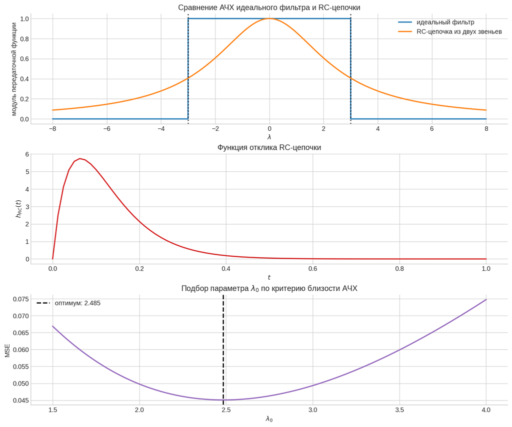

```python
fig, axes = plt.subplots(3, 1, figsize=(12, 10), constrained_layout=True)

lam_show = np.linspace(-8, 8, 4000)
axes[0].plot(lam_show, ideal_transfer(lam_show, lambda_F), label="идеальный фильтр")
axes[0].plot(lam_show, np.abs(rc_transfer_two_stage(lam_show, lambda0_opt)), label="RC-цепочка из двух звеньев")
axes[0].axvline(-lambda_F, color="black", linestyle=":", alpha=0.7)
axes[0].axvline(lambda_F, color="black", linestyle=":", alpha=0.7)
axes[0].set_title("Сравнение АЧХ идеального фильтра и RC-цепочки")
axes[0].set_xlabel("$\\lambda$")
axes[0].set_ylabel("модуль передаточной функции")
axes[0].legend()

mask_h_rc = (th_rc >= 0.0) & (th_rc <= 1.0)
axes[1].plot(th_rc[mask_h_rc], h_rc[mask_h_rc], color="#d62728")
axes[1].set_title("Функция отклика RC-цепочки")
axes[1].set_xlabel("$t$")
axes[1].set_ylabel("$h_{RC}(t)$")

axes[2].plot(lambda0_grid, mse_vals, color="#9467bd")
axes[2].axvline(lambda0_opt, color="black", linestyle="--", label=f"оптимум: {lambda0_opt:.3f}")
axes[2].set_title("Подбор параметра $\\lambda_0$ по критерию близости АЧХ")
axes[2].set_xlabel("$\\lambda_0$")
axes[2].set_ylabel("MSE")
axes[2].legend()

plt.show()
```

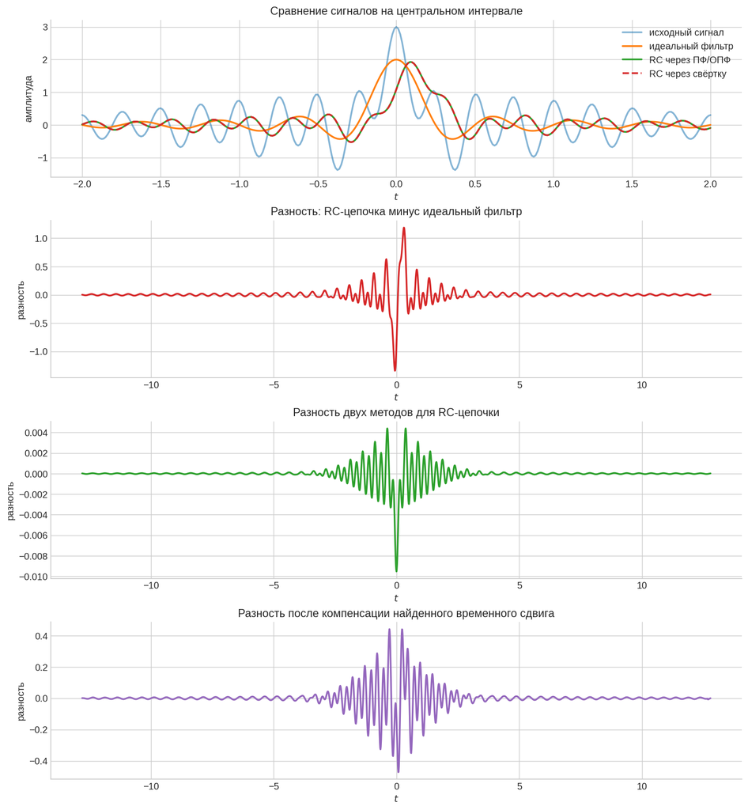

```python
fig, axes = plt.subplots(4, 1, figsize=(12, 13), constrained_layout=True)

mask_zoom = (t >= -2.0) & (t <= 2.0)
axes[0].plot(t[mask_zoom], x[mask_zoom], label="исходный сигнал", alpha=0.55)
axes[0].plot(t[mask_zoom], y_ideal_ft.real[mask_zoom], label="идеальный фильтр")
axes[0].plot(t[mask_zoom], y_rc_ft.real[mask_zoom], label="RC через ПФ/ОПФ")
axes[0].plot(t[mask_zoom], y_rc_conv.real[mask_zoom], "--", label="RC через свёртку")
axes[0].set_title("Сравнение сигналов на центральном интервале")
axes[0].set_xlabel("$t$")
axes[0].set_ylabel("амплитуда")
axes[0].legend()

axes[1].plot(t, y_rc_ft.real - y_ideal_ft.real, color="#d62728")
axes[1].set_title("Разность: RC-цепочка минус идеальный фильтр")
axes[1].set_xlabel("$t$")
axes[1].set_ylabel("разность")

axes[2].plot(t, y_rc_conv.real - y_rc_ft.real, color="#2ca02c")
axes[2].set_title("Разность двух методов для RC-цепочки")
axes[2].set_xlabel("$t$")
axes[2].set_ylabel("разность")

axes[3].plot(t, y_rc_aligned - y_ideal_ft.real, color="#9467bd")
axes[3].set_title("Разность после компенсации найденного временного сдвига")
axes[3].set_xlabel("$t$")
axes[3].set_ylabel("разность")

plt.show()
```

### Комментарий по RC-цепочке

Здесь важны три наблюдения.

**1. RC-цепочка действительно работает как сглаживающий фильтр.**  
Высокочастотная составляющая подавляется, и сигнал становится заметно спокойнее по сравнению с исходным.

**2. RC-цепочка не совпадает с идеальным фильтром.**  
Это нормально и ожидаемо:

- переходная область у RC-фильтра не вертикальная, а плавная;
- амплитуды возле границы полосы уменьшаются постепенно;
- фильтр является причинным, поэтому возникает фазовое и временное запаздывание.

**3. Два способа вычисления результата для одной и той же RC-цепочки совпадают очень хорошо.**  
Это подтверждает корректность вычислений: метод через передаточную функцию и метод через свёртку описывают одну и ту же систему.

На защите это можно сформулировать так:  
идеальный фильтр удаляет нежелательную спектральную область "жёстко", а RC-цепочка делает это "мягко", с неизбежным сглаживанием и сдвигом по времени.

```python
summary = pd.DataFrame([
  {
    "объект сравнения": "идеальный: ПФ/ОПФ vs свёртка",
    "относительная ошибка": ideal_metrics["relative_error_methods"],
  },
  {
    "объект сравнения": "идеальный vs ожидаемая низкочастотная часть",
    "относительная ошибка": ideal_metrics["relative_error_vs_expected_lowfreq"],
  },
  {
    "объект сравнения": "RC: ПФ/ОПФ vs свёртка",
    "относительная ошибка": rc_metrics["relative_error_methods"],
  },
  {
    "объект сравнения": "RC vs идеальный фильтр",
    "относительная ошибка": rc_metrics["relative_error_vs_ideal"],
  },
  {
    "объект сравнения": "RC vs идеальный после компенсации сдвига",
    "относительная ошибка": rc_metrics["relative_error_vs_ideal_after_best_shift"],
  },
])

summary
```

|  | объект сравнения | относительная ошибка |
| --- | --- | --- |
| 0 | идеальный: ПФ/ОПФ vs свёртка | 0.000021 |
| 1 | идеальный vs ожидаемая низкочастотная часть | 0.001637 |
| 2 | RC: ПФ/ОПФ vs свёртка | 0.005159 |
| 3 | RC vs идеальный фильтр | 0.773679 |
| 4 | RC vs идеальный после компенсации сдвига | 0.361549 |

## 5. Краткие ответы по пунктам задания

### Идеальный фильтр

1. **Частоты ярко выраженных колебаний:**
   это области около $$\lambda=\pm 4$$, соответствующие гауссово-модулированной косинусоиде.
2. **Выбор полосы:**
   выбрана полоса $$ [-\lambda_F,\lambda_F]=[-3,3]. $$
3. **Фильтрация через ПФ и ОПФ:**  
   выполнена, результат получен и визуализирован.
4. **Фильтрация через свёртку с функцией отклика:**  
   выполнена, результат получен и визуализирован.
5. **Сравнение двух результатов идеального фильтра:**  
   результаты практически совпадают, расхождение очень мало.

## 6. Итоговые выводы

В работе продолжен анализ сигнала из ДЗ-1 и выполнена его фильтрация двумя типами фильтров.

Главные выводы:

Итак, цель работы достигнута: показано, как один и тот же сигнал проходит через идеальный и реальный аналоговый фильтры, и подробно исследовано, в чём именно их сходство и различие.

## 7. Что можно сказать на защите

Короткая версия содержательного комментария:

- исходный сигнал содержит низкочастотную $$\mathrm{sinc}$$-часть и колебательную часть с пиками около $$\pm 4$$;
- поэтому полоса $$[-3,3]$$ сохраняет полезную низкочастотную составляющую и убирает яркие колебания;
- идеальный фильтр в частотной области задаётся прямоугольником, а его отклик во времени имеет вид $$2\lambda_F\,\mathrm{sinc}(2\lambda_F t)$$;
- RC-цепочка - это физически реализуемый фильтр, поэтому её АЧХ плавная, а не ступенчатая;
- именно из-за причинности и плавного спада RC-цепочка даёт запаздывание и не повторяет идеальный фильтр в точности;
- при этом результаты через свёртку и через преобразование Фурье для каждой системы совпадают, что подтверждает правильность реализации.

Этого комментария обычно достаточно, чтобы уверенно объяснить и графики, и смысл вычислений.